# mmir: An R-package for Simple Biological Metric Calculations

Zachary M. Smith

2020-02-07

# Objective

- Demonstrate the functionality provided by the **mmir** R-package for calculating biological metrics for the development and/or use in an MMI or IBI.

# What is an MMI?

- Multi-Metric Indices (MMIs) or Indices of Biotic Integrity (IBIs) are models that summarize multiple aspects of a biological community of interest (e.g., richness, diversity, relative abundance, tolerance, and functional feeding group) into a single numeric or categorical value representing ecological condition.
  - considered a robust measure of water quality becuase it represents more than a snapshot in time
  - have been around for nearly 40 years

# Need

- MMIs are widely used by U.S. federal and state agencies to assess water quality but there is no R-package available to simplify and standardize metric calculations.

# R Packages: Brief Description

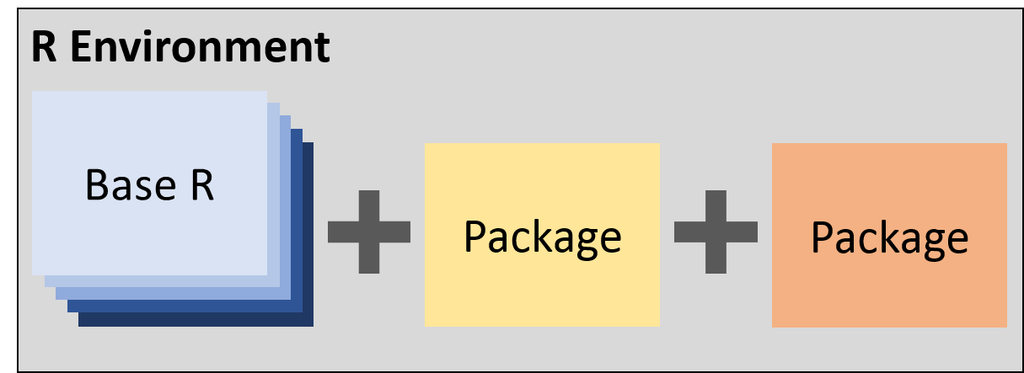

# R Functions: Brief Description

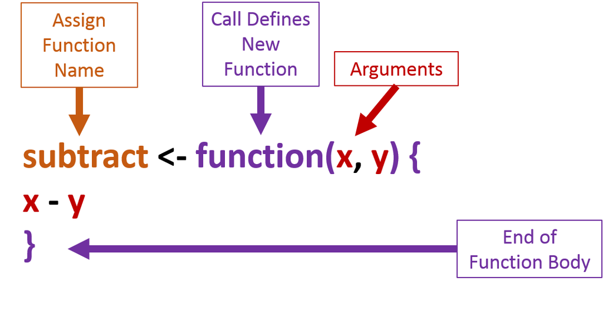

# Tidyverse

[figure not shown]

# Installation of mmir

Install the Multi-Metric Index (MMI) package, **mmir**, that I am developing from GitHub (https://github.com/zsmith27/mmir).

```r
devtools::install_github("zsmith27/mmir")
```

# Load the Package

Once **mmir** is installed, load the package with `library()`.

```r
library(mmir)
```

# Required Data Format

- **Requirements**
  - Each row should represent the number of individuals enumerated for a single taxon collected during a single sampling event.
  - There should be columns representing:
    - a unique ID for a sampling event (i.e., key)
    - taxonomic counts
    - various taxonomic ranks (e.g., individual columns for order, family, genus)
    - various taxonomic groups (e.g., tolerance values and functional feeding groups)

# Required Data Format Example

| unique_id | reporting_value | final_id | order | family | genus |
| --- | --- | --- | --- | --- | --- |
| caz_1_1 | 1 | physa | basommatophora | physidae | physa |
| caz_1_1 | 1 | gyraulus | basommatophora | planorbidae | gyraulus |
| caz_1_1 | 5 | bezzia | diptera | ceratopogonidae | bezzia |
| onon_1_1 | 1 | valvata | heterostropha | valvatidae | valvata |
| onon_1_1 | 40 | chironomus | diptera | chironomidae | chironomus |
| onon_1_1 | 2 | cryptotendipes | diptera | chironomidae | cryptotendipes |

# Getting Started

Load example data included within the package.

```r
data("onondaga", package = "mmir")
```

Prepare the data for metric calculation.

```r
nest.df <- onondaga %>%
  group_nest(unique_id, .key = "data")
```

# Metric Function Arguements

- `.data` = A data frame where each row should represent the number of individuals enumerated for a single taxon collected during a single sampling event.
- `.key_col` = A single column that represents a unique ID or key (i.e., site ID) that can be used to group the data.
- `.counts_col` = A single numeric column that represents taxonomic counts.
- `.group_col` = A single column that represents a taxomic rank or group of interest.
- `.keep_col` = A column name used in combination with `.keep_vec` to subset the `.data`.
- `.keep_vec` = A vector of values found in `.keep_col` that will be used to subset `.data`.
- `.drop_col` = A column name used in combination with `.drop_vec` to exclude rows from the calculation.
- `.drop_vec` = A vector of values found in `.drop_col` that will be removed from the calculation.

# Metric Function List

1. Richness: `taxa_rich()`
2. Relative Richness: `taxa_pct_rich()`
3. Abundance: `taxa_abund()`
4. Relative Abundance: `taxa_pct()`
5. Diversity Indices: `taxa_div()`
6. Dominance: `taxa_dom()`
7. Tolerance Indices: `taxa_tol()`

## Richness

```r
taxa_rich(.data = nest.df,
          .key_col = unique_id,
          .group_col = family)
```

```
##  [1] 13 13 21 19 11 12 13 11 14 13 11  9 10 13 14 10 14 10 12 11 11 10 13 13  9
## [26]  7 14 13 16 10 13  7  2  2  2  3  3  6  2  3  4  3  3  2  7  7  6  5  5  9
## [51]  5  9  5  7  5  6  9  6  7  7  5  7  2  2 12 15  8  6 10  6  5  8  8  4 10
## [76]  6 12  6  6  9  2  3  5  9 13  7  8 11  8  7  9  6  7 10  5  4
```

```r
nest.df <- nest.df %>%
  mutate(rich_fam = taxa_rich(
    .data = .,
    .key_col = unique_id,
    .group_col = family
  ))
```

|  | unique_id | data | rich_fam |
| --- | --- | --- | --- |
| 1 | caz_1_1 | List of 35 Variables | 13 |
| 2 | caz_1_2 | List of 35 Variables | 13 |
| 3 | caz_10_1 | List of 35 Variables | 21 |
| 4 | caz_10_2 | List of 35 Variables | 19 |
| 5 | caz_11_1 | List of 35 Variables | 11 |
| 6 | caz_11_2 | List of 35 Variables | 12 |
| 7 | caz_12_1 | List of 35 Variables | 13 |
| 8 | caz_12_2 | List of 35 Variables | 11 |
| 9 | caz_13_1 | List of 35 Variables | 14 |
| 10 | caz_13_2 | List of 35 Variables | 13 |

[output cut: 86 more lines]

## EPT Richness

```r
nest.df <- nest.df %>%
  mutate(
    rich_ept_genus = taxa_rich(
      .data = .,
      .key_col = unique_id,
      .group_col = family,
      .keep_col = order,
      .keep_vec = c("ephemeroptera",
                    "plectoptera",
                    "trichoptera")
    )
  )
```

| unique_id | data | rich_fam | rich_ept_genus |
| --- | --- | --- | --- |
| caz_1_1 | List of 35 Variables | 13 | 3 |
| caz_1_2 | List of 35 Variables | 13 | 3 |
| caz_10_1 | List of 35 Variables | 21 | 5 |
| caz_10_2 | List of 35 Variables | 19 | 4 |
| caz_11_1 | List of 35 Variables | 11 | 3 |
| caz_11_2 | List of 35 Variables | 12 | 2 |

## Relative Abundance

```r
nest.df <- nest.df %>%
  mutate(
    pct_ept = taxa_pct(
      .data = nest.df,
      .key_col = unique_id,
      .counts_col = reporting_value,
      .keep_col = order,
      .keep_vec = c("ephemeroptera",
                    "plecoptera",
                    "trichoptera")
    )
  )
```

| unique_id | data | rich_fam | rich_ept_genus | pct_ept |
| --- | --- | --- | --- | --- |
| caz_1_1 | List of 35 Variables | 13 | 3 | 16.964286 |
| caz_1_2 | List of 35 Variables | 13 | 3 | 6.000000 |
| caz_10_1 | List of 35 Variables | 21 | 5 | 8.875740 |
| caz_10_2 | List of 35 Variables | 19 | 4 | 8.571429 |
| caz_11_1 | List of 35 Variables | 11 | 3 | 5.932203 |
| caz_11_2 | List of 35 Variables | 12 | 2 | 6.603774 |

## Diverisity Indices

```r
nest.df <- nest.df %>%
  mutate(
    div_simpson_genus = taxa_div(
      .data = nest.df,
      .key_col = unique_id,
      .group_col = genus,
      .counts_col = reporting_value,
      .job = "simpson"
    ),
    div_shannon_genus = taxa_div(
      .data = nest.df,
      .key_col = unique_id,
      .group_col = genus,
      .counts_col = reporting_value,
      .job = "shannon",
      .base = 2
    )
  )
```

| unique_id | data | rich_fam | rich_ept_genus | pct_ept | div_simpson_genus | div_shannon_genus |
| --- | --- | --- | --- | --- | --- | --- |
| caz_1_1 | List of 35 Variables | 13 | 3 | 16.964286 | 0.1417411 | 3.488295 |
| caz_1_2 | List of 35 Variables | 13 | 3 | 6.000000 | 0.1188000 | 3.740104 |
| caz_10_1 | List of 35 Variables | 21 | 5 | 8.875740 | 0.1001716 | 3.883571 |
| caz_10_2 | List of 35 Variables | 19 | 4 | 8.571429 | 0.0848073 | 4.102988 |
| caz_11_1 | List of 35 Variables | 11 | 3 | 5.932203 | 0.2219190 | 2.871120 |
| caz_11_2 | List of 35 Variables | 12 | 2 | 6.603774 | 0.1181915 | 3.667286 |

# Acknowledgements

- Interstate Commission on the Potomac River Basin (ICPRB)
  - With a special thank you to Dr. Claire Buchanan
- New York State Department of Environmental Conservation (NYSDEC)
  - With a special thank you to Dr. Alexander J. Smith

# Contact Information

- **Name:** Zachary M. Smith
- **Email:** zachary.smith2@dec.ny.gov
- **GitHub:** https://github.com/zsmith27
  - **mmir:** https://github.com/zsmith27/mmir